# Отчет по лабораторной работе №8

Настройка SMTP-сервера

Виноградова М.А

Российский университет дружбы народов, Москва, Россия

18 октября 2026

# Информация

## Докладчик

- Виноградова Мария Андреевна
- студентка НПИбд-02-24
- номер студ. билета 1132240691
- Российский университет дружбы народов
- 1132240691@rudn.ru
- https://github.com/mavinogradova/study_2026-2027

# Цель работы

Приобретение практических навыков по установке и конфигурированию SMTP-сервера.

# Задание

1. Установите на виртуальной машине server SMTP-сервер postfix (см. раздел 8.4.1).
2. Сделайте первоначальную настройку postfix при помощи утилиты postconf, задав отправку писем не на локальный хост, а на сервер в домене (см. раздел 8.4.2).
3. Проверьте отправку почты с сервера и клиента (см. раздел 8.4.3).
4. Сконфигурируйте Postfix для работы в домене. Проверьте отправку почты с сервера и клиента (см. раздел 8.4.4).
5. Напишите скрипт для Vagrant, фиксирующий действия по установке и настройке Postfix во внутреннем окружении виртуальной машины server. Соответствующим образом внесите изменения в Vagrantfile (см. раздел 8.4.5).

# Выполнение лабораторной работы

## Установка Postfix. Вход на server

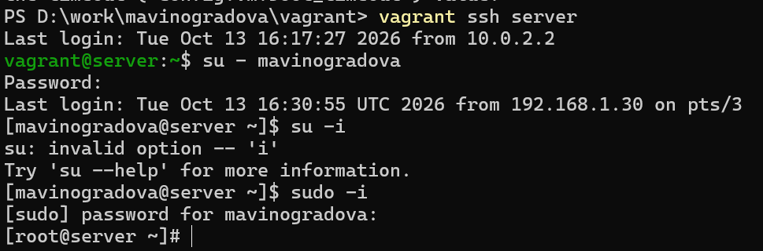

Вход на виртуальную машину server под пользователем mavinogradova и переход в режим суперпользователя

## Установка Postfix. Установка пакетов

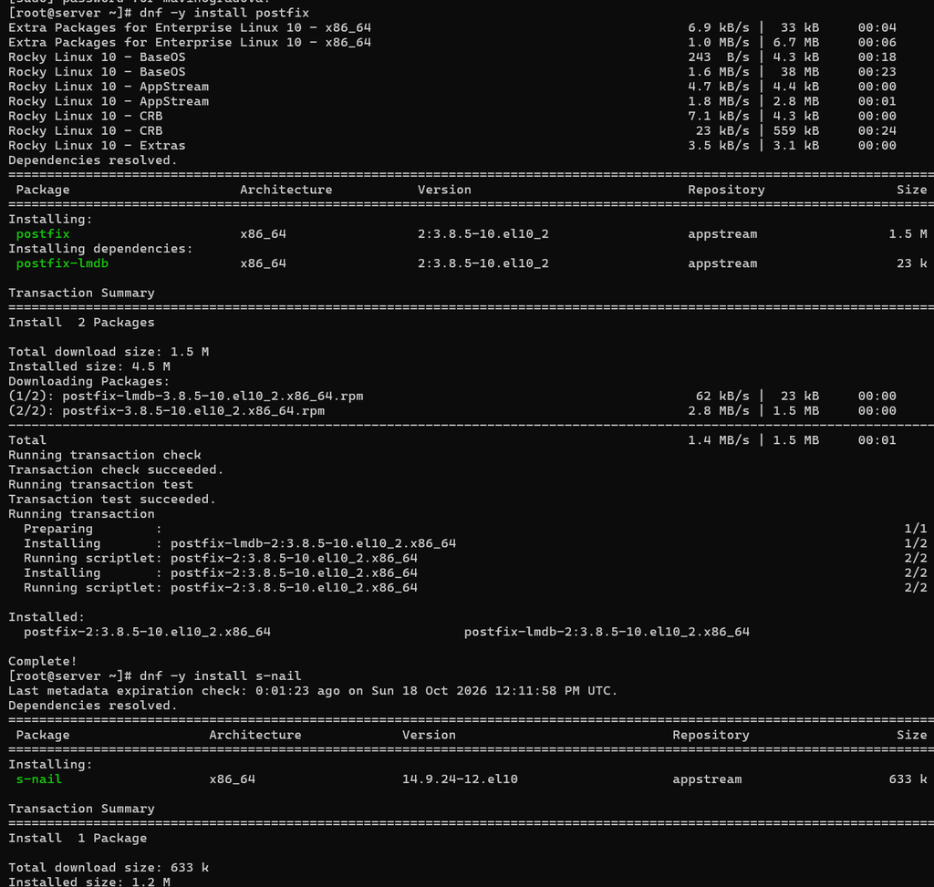

Установка пакетов postfix и s-nail на сервере

## Установка Postfix. Настройка firewall и запуск

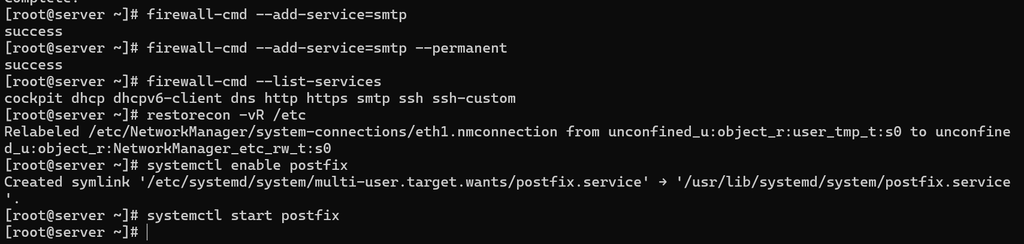

Настройка межсетевого экрана, восстановление контекста SELinux и запуск Postfix

## Изменение параметров. Просмотр конфигурации

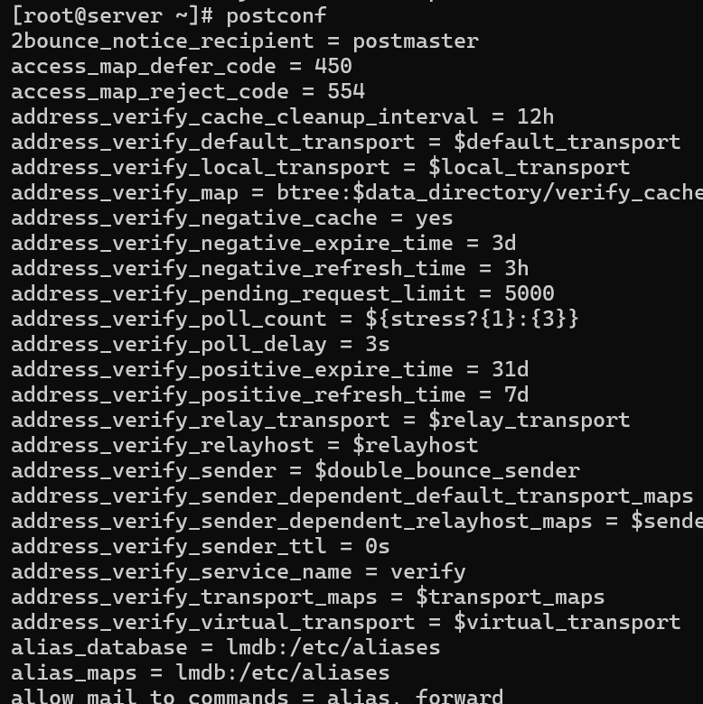

Просмотр полного списка текущих параметров Postfix

## Изменение параметров. myorigin и mydomain

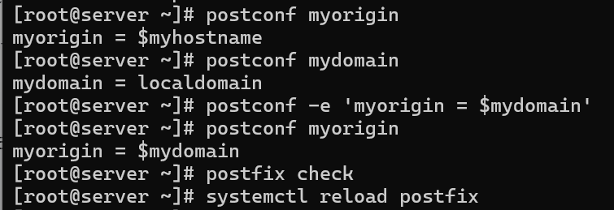

Просмотр и изменение параметров myorigin и mydomain, проверка конфигурации

## Изменение параметров. postconf -n

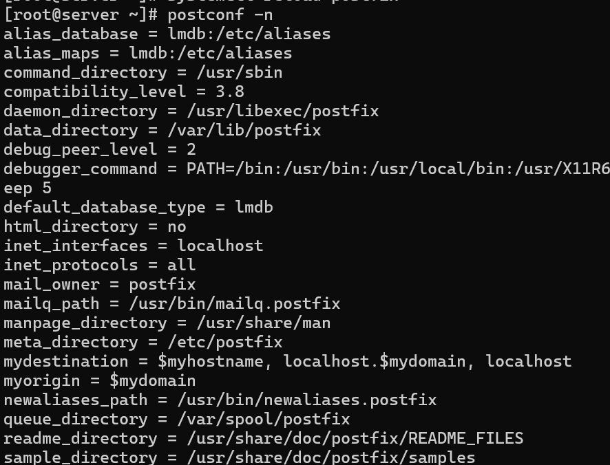

Просмотр параметров Postfix, отличных от значений по умолчанию

## Изменение параметров. Задание домена и IPv4

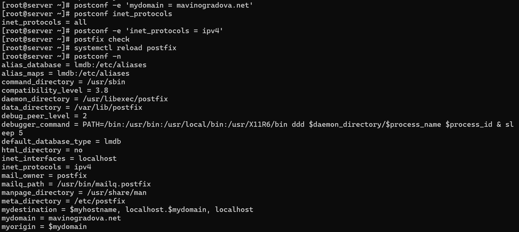

Жесткое задание домена, отключение IPv6 и перезагрузка конфигурации

## Проверка работы. Отправка с сервера

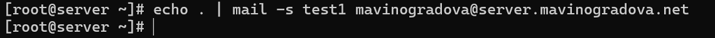

Отправка тестового письма с сервера

## Проверка работы. Лог сервера

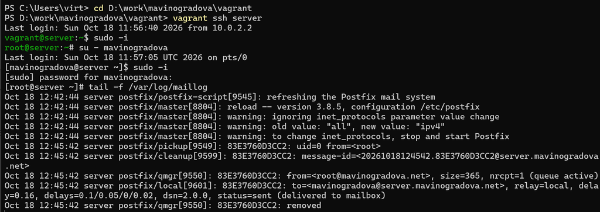

Мониторинг лога maillog на сервере, подтверждение доставки письма

## Проверка работы. Вход на client

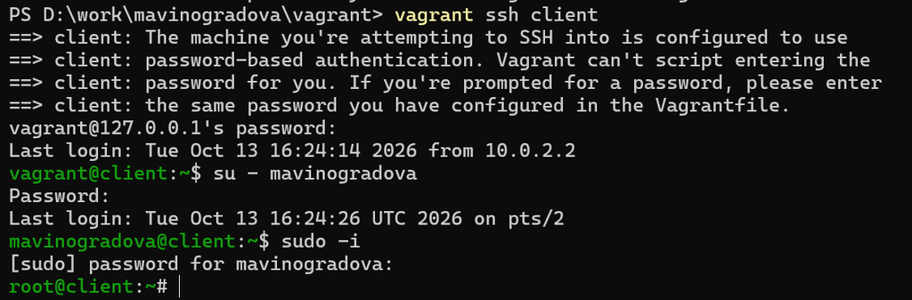

Вход на виртуальную машину client и переход в режим суперпользователя

## Проверка работы. Установка на client

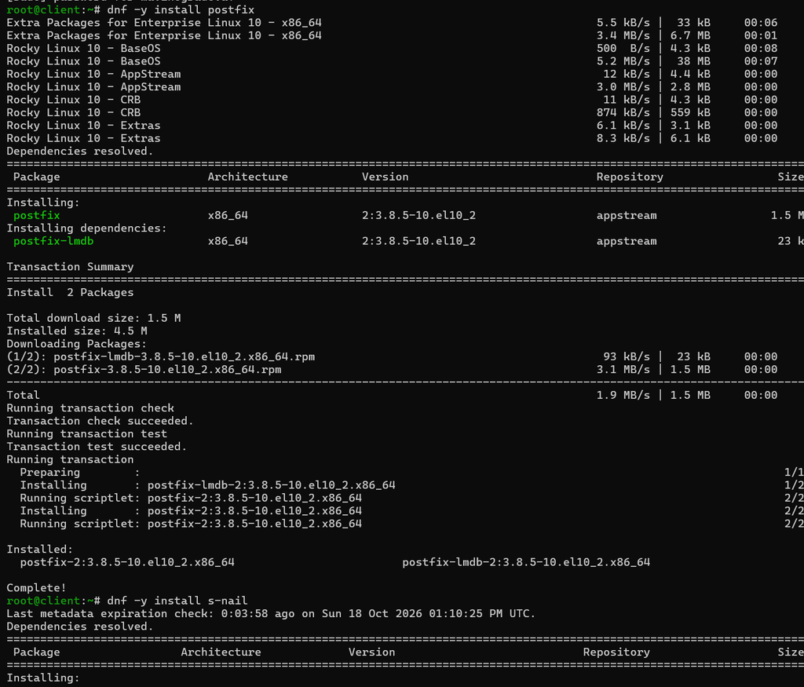

Установка пакетов postfix и s-nail на клиенте

## Проверка работы. Настройка на client

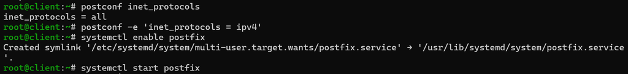

Настройка IPv4 и запуск Postfix на клиенте

## Проверка работы. Отправка с client

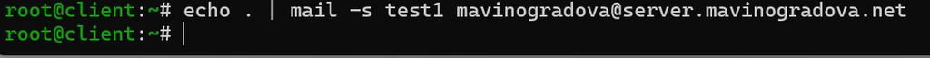

Отправка письма с клиента

## Проверка работы. Ожидание в очереди

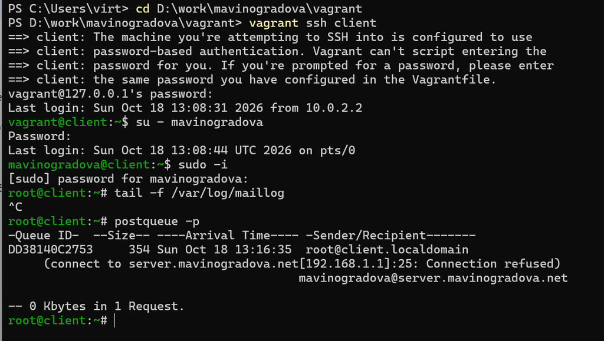

Проверка очереди на клиенте: письмо ожидает отправки

## Проверка работы. Настройка сети на сервере

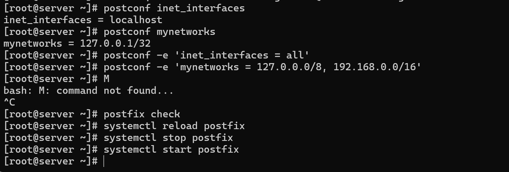

Настройка сетевых интерфейсов и доверенных сетей на сервере

## Проверка работы. Повторная отправка

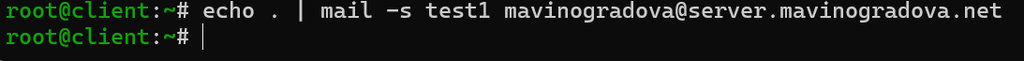

Повторная отправка письма с клиента после настройки сети

## Проверка работы. Успешная доставка

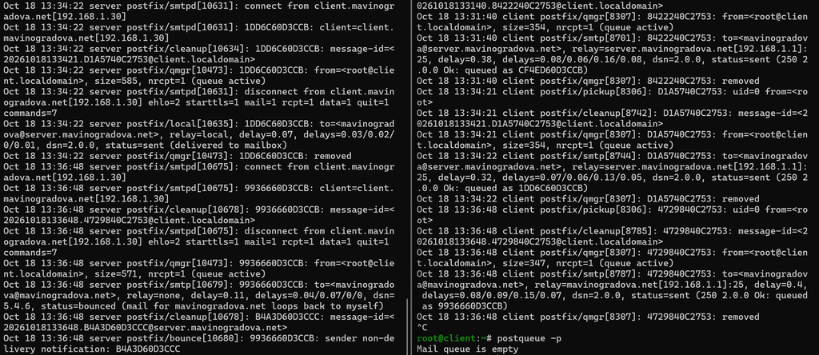

Логи сервера и клиента, подтверждающие успешную доставку письма

## Конфигурация для домена. Отправка на домен

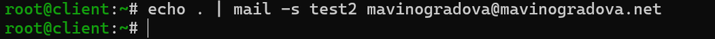

Отправка письма на доменный адрес с клиента

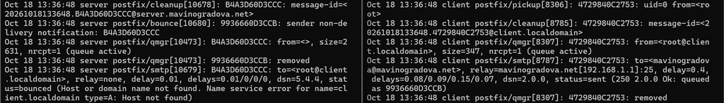

Логи сервера и клиента при отправке письма на доменный адрес

## Конфигурация для домена. Проверка очереди

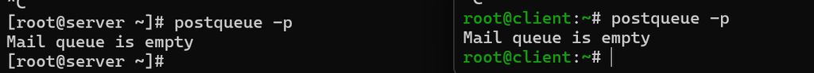

Проверка очереди на сервере и клиенте

## Конфигурация для домена. Прямая зона

[figure not shown]

Редактирование файла прямой DNS-зоны с добавлением MX-записи

## Конфигурация для домена. Обратная зона

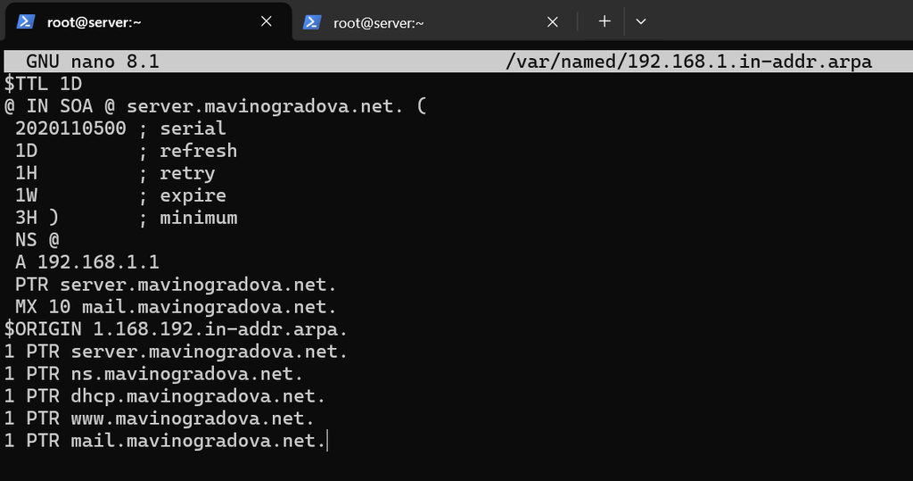

Редактирование файла обратной DNS-зоны

## Конфигурация для домена. mydestination и DNS

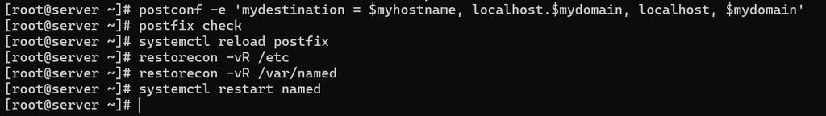

Настройка mydestination, перезагрузка Postfix и DNS

## Конфигурация для домена. Проталкивание очереди

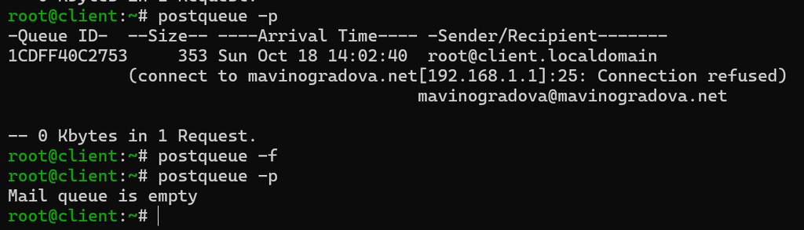

Проталкивание очереди и проверка её состояния на клиенте

## Конфигурация для домена. Успешная доставка

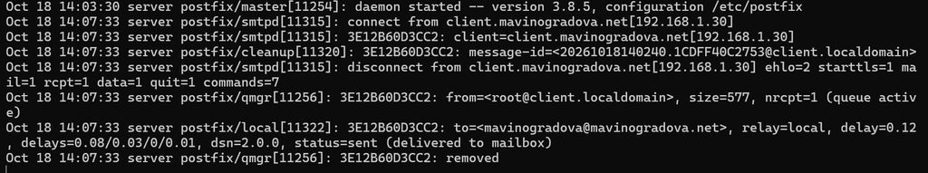

Лог сервера, подтверждающий успешную доставку письма на доменный адрес

## Окружение ВМ. Создание mail.sh на сервере

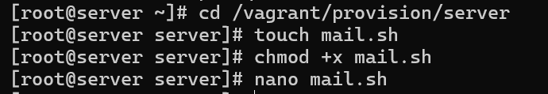

Создание исполняемого файла mail.sh в каталоге провижининга сервера

## Окружение ВМ. Содержимое mail.sh на сервере

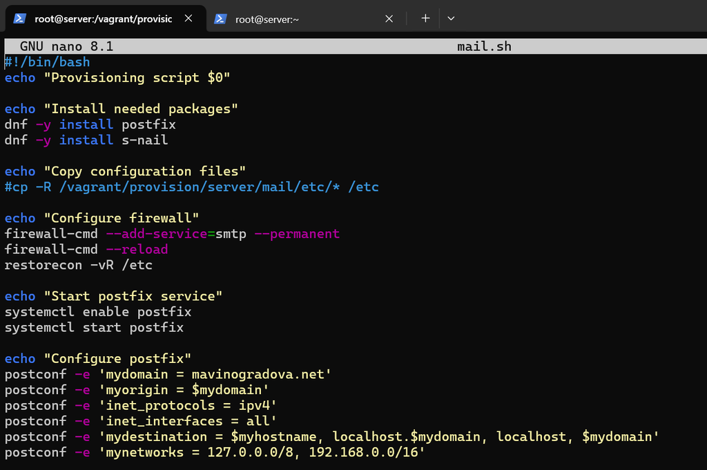

Содержимое скрипта provision/server/mail.sh

## Окружение ВМ. Создание mail.sh на клиенте

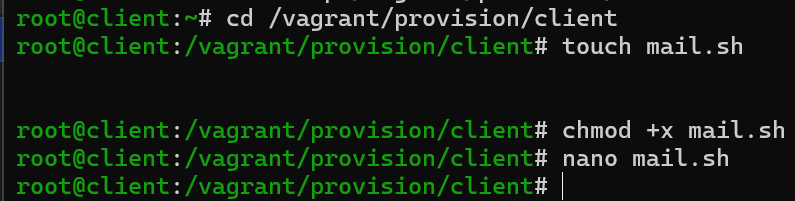

Создание исполняемого файла mail.sh в каталоге провижининга клиента

## Окружение ВМ. Содержимое mail.sh на клиенте

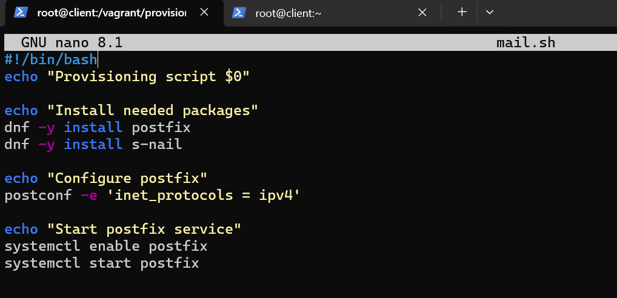

Содержимое скрипта provision/client/mail.sh

## Окружение ВМ. Правка Vagrantfile (client)

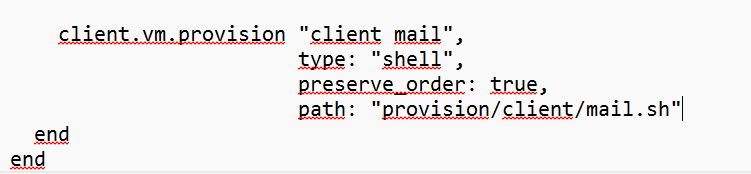

Фрагмент Vagrantfile с добавленным блоком провижининга client mail

## Окружение ВМ. Правка Vagrantfile (server)

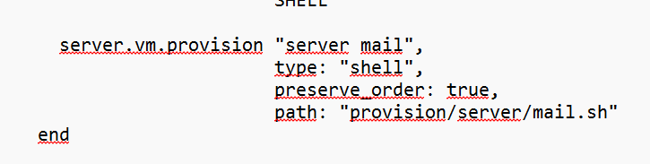

Фрагмент Vagrantfile с добавленным блоком провижининга server mail

# Выводы

В ходе лабораторной работы были приобретены практические навыки по установке и конфигурированию SMTP-сервера. Был установлен и настроен Postfix на сервере и клиенте, изучены основные параметры конфигурации (`mydomain`, `myorigin`, `mydestination`, `inet_interfaces`, `mynetworks`). Проверена работа почтовой службы: отправка писем с сервера и клиента, анализ логов доставки и очереди сообщений. Настроены DNS-зоны с MX-записями для корректной работы доменной почты. Автоматизированы действия по установке и настройке Postfix с помощью скриптов провижининга для Vagrant.